# Batch Correction

ALSF CCDL - Candace Savonen

*Purpose*: This notebook illustrates how to assess batch effects with principal components analysis and then attempt to correct batch effects with `limma`.

It’s good practice to assess the structure of any dataset you receive from refine.bio. The refine.bio [refine.bio normalization pipeline](http://docs.refine.bio/en/latest/main_text.html#processing-information), completed prior to your download, may have sufficiently minimized batch effects.

Traditionally, batch effects are framed in terms of technical batches, or in other words, what samples were processed when and in what groups in an individual experiment. However, most publicly available data does not include this information and differences may exists between samples from different platforms or datasets once they are integrated.

For datasets with similar set ups, on refine.bio, we can aggregate data using the ‘by species’ option on refine.bio. But, another source of batch effects can be differences among datasets aggregated together. In this example, we will use expression datasets collected from acute myeloid leukemia patients. This aggregated dataset consists of four original datasets we aggregated using the ‘by species’ option on refine.bio.

Two of these datasets are RNA-seq data:  
- [SRP048759](https://www.refine.bio/experiments/SRP048759/leucegene-aml-sequencing-part-3)  
- [SRP033266](https://www.refine.bio/experiments/SRP033266/leucegene-aml-sequencing-part-2)

The other two are measured on a hgu133plus2 microarray:  
- [GSE6891](https://www.refine.bio/experiments/GSE6891/acute-myeloid-leukemia-samples-of-samples-60yrs-on-hg-u133-plus-2)  
- [GSE14468](https://www.refine.bio/experiments/GSE14468/gene-expression-profiling-of-cebpa-double-and-single-mutant-and-cebpa-wild-type-aml)

Although the normalization processing for these data makes the data more comparable, data from different platforms may show differences. This is something we can try to address with batch correction.

### General requirements for performing batch correction:

#### 1) Have adequate sample sizes per batch

For batch correction to work you need adequate sample size (> 10 at least) for each batch group. In this example, we will consider the original datasets and platforms as possible batch variables to consider correcting by.

#### 2) Cannot have batches confounded with and other biological variables

If batches also have other differences such as tissue type, treatments, or any other biologically meaningful variable, batch correction cannot be completed without severely compromising the integrity and meaning of the data.

#### 3) Evaluate data structure pre- and post-batch correction

Batch correction isn’t always necessary, nor is it able to completely get rid of batch effects. We recommend careful evaluation of your data before and after correction. In this notebook, we will use principal components analysis to observe how samples group together. As a dimension reduction technique, PCA allows us to plot the first two components scores of our samples so we can see how they might cluster by variables that are potential sources of batch effects.

## 1) Set up

This will install `limma` for you if you haven’t installed it before. We recommend looking through [`limma`’s guide](https://bioconductor.org/packages/release/bioc/vignettes/limma/inst/doc/usersguide.pdf) for further information.

```r
if (!("limma" %in% installed.packages())) {
  # Install limma
  BiocManager::install("limma", update = FALSE)
}
```

```r
# Magrittr pipe
`%>%` <- dplyr::`%>%`
# Load ggplot2 for graphing
library(ggplot2)
```

```r
# Make a results directory if it isn't created yet
if (!dir.exists("results")) {
  dir.create("results")
}
# Make a plots directory if it isn't created yet
if (!dir.exists("plots")) {
  dir.create("plots")
}
```

## 2) Import and set up data

Data downloaded from refine.bio include a metadata tab separated values (“TSV”) file and a data TSV file. These files were obtained from [refine.bio](https://www.refine.bio/) by entering the search term “AML” and then aggregating by `species`.

```r
# Put name of data file
data.filename <- file.path("data", "HOMO_SAPIENS.tsv")
# Read in data tsv file
df <- readr::read_tsv(data.filename, progress = FALSE) %>%
  tibble::column_to_rownames("X1")
# Make the gene column the rownames so the gene names are out of the way for calculations
```

Prep metadata and make sure it matches the order of the samples in `df`.

```r
# Metadata file name
metadata.filename <- file.path("data", "metadata_HOMO_SAPIENS.tsv")
# Read in data tsv file
metadata <- readr::read_tsv(metadata.filename, progress = FALSE)
# Put samples in the same order in the dataframe
df <- df %>% dplyr::select(metadata$refinebio_accession_code)
# Check if the samples are in the same order
all.equal(metadata$refinebio_accession_code, colnames(df))
```

```
[1] TRUE
```

## 3) Set up batch information.

For this batch correction, we will want both original dataset information as well as platform information.

Set up the platform information.

```r
# Get rid of spaces to streamline things
metadata$refinebio_platform <- gsub(" ", "", metadata$refinebio_platform)
# Make into a factor
platform <- as.factor(metadata$refinebio_platform)
```

Set up the dataset of origin information.

```r
# Make a dataset vector
dataset <- metadata$series_id
# This is hacky and will be removed after we have a 'dataset' metadata column deployed
dataset[grep("SRR16", metadata$refinebio_accession_code)] <- "SRP048759"
dataset[grep("SRR10", metadata$refinebio_accession_code)] <- "SRP033266"
# Make this a factor
dataset <- as.factor(dataset)
# Look at the summary of how many samples we have per dataset
summary(dataset)
```

```
['GSE6891', 'GSE14468']                GSE14468                 GSE6891               SRP033266
                    461                      64                      50                     144
              SRP048759
                    434
```

## 4) Perform Principal Components Analysis (PCA)

In order to observe how samples group together, we will use PCA for dimension reduction so that we can plot the PC scores of the samples. For more information on PCA and other dimension reduction techniques, we recommend our [dimension reduction examples](https://github.com/AlexsLemonade/refinebio-examples/blob/master/dimension-reduction) in this repository.

```r
# Calculate PCA
pca <- prcomp(t(df))
# Make into dataframe for plotting with ggplot2
pca.df <- data.frame(pca$x[, 1:2])
```

Plot these PC scores and look for how samples of different platforms and datasets cluster.

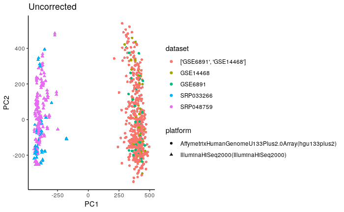

```r
# Create a scatterplot
pc.plot <- ggplot(
  pca.df,
  aes(x = PC1, y = PC2, color = dataset, shape = platform)
) +
  geom_point() +
  ggtitle("Uncorrected") +
  theme_classic()
# Print out the plot here
pc.plot
```

In this example dataset, we notice this batch effect appears to be due to differences in platforms. The group of samples on either the left or right clusters are from multiple different datasets, but on the left is RNA-seq data while on the right is all hgu133plus2 microarray data.

Save plot to a PNG.

```r
# Save the plot to a png
ggsave(file.path("plots", "uncorrected_pca_plot.png"))
```

## 5) Peform batch correction using limma

Here we will use the `platform` variable to correct by. Because we didn’t see much separation in datasets of the same platform, we won’t use our `dataset` variable to correct.

```r
# Use removeBatchEffect function from limma
corrected.df <- limma::removeBatchEffect(df, batch = platform)
```

## 6) Re-evaluate PCA after batch correction

Let’s see if batch correction helped with making PC scores less divided by platform.

```r
# Calculate PCA
corrected.pca <- prcomp(t(corrected.df))
# Make into dataframe for plotting with ggplot2
corrected.pca.df <- data.frame(corrected.pca$x[, 1:2])
```

Plot these batch corrected data PC scores.

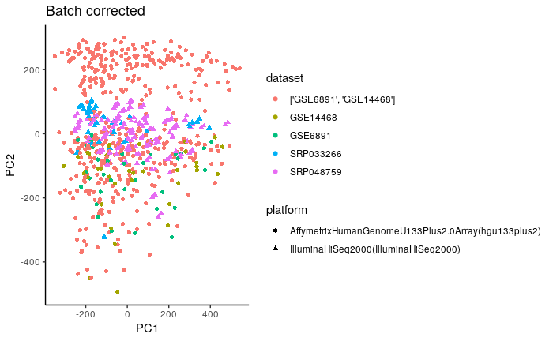

```r
# Create a scatterplot, same as before, but with the corrected data
pc.plot <- ggplot(
  corrected.pca.df,
  aes(x = PC1, y = PC2, color = dataset, shape = platform)
) +
  geom_point() +
  ggtitle("Batch corrected") +
  theme_classic()
# Print out the plot here
pc.plot
```

Although the correction doesn’t completely get rid of the batch effects on PC2, it clearly reduces the effect of the batch effect on PC1. This an example of how batch correction can help, but will probably not get rid of the problem entirely. Depending on what analyses these data were being used for, we may need to consider analyzing these datasets separately, or moving forward with only samples of one platform type.

Save plot with batch corrected PCA plot to a PNG.

```r
ggsave(file.path("plots", "batch_corrected_pca_plot.png"))
```

## 7) Save batch corrected data to TSV file

We will save the batch-corrected dataframe to a TSV file.

```r
corrected.df %>%
  as.data.frame() %>%
  tibble::rownames_to_column("Gene") %>%
  readr::write_tsv(file.path("results", "batch_corrected_exprs.tsv"))
```